# CH_13

Steph Jordan

2/20/2022

## Chapter 13

1a. The error is 9-(2+3*2)=1 (note: “error” is used here because we have access to the “true” model, and are assessing the difference between the observed and actual Y values?)

1b. The residual is 9-(1.9+3.1*2)=0.9 (note: “residual” is used here because we only have access to the approximated regression model of Y, and are assessing the difference between the observed and regression-estimated value of Y?)

2. Regression equation:
   $$Y=\beta0+\beta1*X+\beta2*A+\beta3*B +\epsilon$$

3a. For every one unit increase in X, Y increases by 3.

3b. The t-statistic is our means of assessing whether a coefficient is statistically significant. We can calculate the t-statistic by dividing the coefficient by its standard error, as follows:

```r
3/1.3
```

```
## [1] 2.307692
```

Since 2.3>1.96, we know that the coefficient lies above the 97.5th percentile, meaning that it is significant at the 95% level.

We can also calculate the exact percentile this estimate falls at:

```r
#do coefficient estimate divided by standard deviation
pnorm(q=(3/1.3))
```

```
## [1] 0.9894919
```

98 is above the 97.5th percentile, so we have confirmed that this estimate is significant at the 95% level.

3c. There is less than a 5% chance that we would see a B1 value at least this far from 0 based on sampling variation alone (i.e., based on the assumption that the null hypothesis is true).

4a. A one unit increase in years of education is associated with 76.185 additional hours worked.

4b. The standard error is 19.693.

4c. The predicted number of hours worked is 306.553.

4d. There are 3382 observations

4e. Yes. Since the ‘children under 5’ coefficients in both models have three *’s, we know it is significant at the 99% level, which includes the 95% level.

5a. We can take the derivative of the polynomial equation:
$$110.23 - 2*1.581*YearsEducation=110.23-3.162*YearsEducation$$

5b. Using above equation, we can plug in 16:

```r
110.23-3.162*16
```

```
## [1] 59.638
```

A one-unit increase in years of education increases annual hours worked by 59.638.

5c. The relationship is getting less positive for higher values of YearsEducation.

5d. Adding many polynomial powers to the model makes the model increasingly harder to interpret. Additionally, higher-order terms might make the model more complex without actually improving its fit. Lastly, there is also the risk of ‘overfitting’, in which your model becomes too highly responsive to the data, and maybe even begins to fit noise. When a model is too closely matched to the training data set, it will fail to generalize well when applied to other datasets.

6a. Being a homeowner is associated with a 50.174 hour increase in annual hours worked on average.

6b. Calculation below

```r
923.904-773.412
```

```
## [1] 150.492
```

On average, people with 4 children under the age of 5 work 150.492 hours fewer than people with 3 children under the age of 5.

6c. We cannot tell whether there’s a statistically significant difference in hours worked between having 2 children and having 3 children under the age of 5 from this table. If we are assessing whether a categorical variable has a significant effect as a whole, we need to look at all the category coefficients rather than the individual coefficients. This is achieved through a “joint F test,” where you compare the predictive power of the model against a version where the categorical variable has been removed as a predictor.

7a. For every one unit increase in education, hours worked increases by 110.073 hours. There is an interaction between home ownership and education, but since we are also accounting for homeownership in model 1, and this question asks solely about the relationship between education and hours worked, we only consider the direct relationship, and not the moderating effect of homeownership on the relationship between education and hours worked.

7c. The effect of a one unit increase in education on annual hours worked is 53.994 times weaker when the individual is a homeowner.

7d. A one unit increase in education is associated with a 0.067 unit increase in log(Annual Hours Worked), which translates into a 6.7% increase in annual hours worked.

7e. A 10% increase in education is associated with a 0.1 unit change in log(education), which is associated with a 0.1*832.347=83.2347-unit change in annual hours worked.

7f. With log models, 0-values are not compatible. So therefore, model 2 and 3, which include logged variables, involve excluding 0-value variables and decreasing the sample size.

8. When error terms are correlated across time, such that knowing the error term in one period gives us some information about the error term in the next period (B)
9. A, B
10. The pollsters could apply inverse sampling probability weights, which would allow them to accomodate for the different representations of demographic groups in their sample. By giving data points from each demographic group in the sample a weight proportionate to their prevalence in the population, the pollsters could re-weight their sample to represent each demographic group in proportion to its presence in the population.
11. You’re doing research on unusual sexual practices. You ask people whether they’ve ever engaged in these weird practices, which many people might prefer to keep secret, even if they’ve actually done them (A). There would be under-reporting with regard to engagement in unusual sexual practices, which would lead to systematic, non-classical error.

## Coding Exercises

```r
library(tidyverse)
library(modelsummary)
library(margins)
```

Follow the below instructions and turn in both your code and results:

1. Load the `dengue.csv` file provided to you, or from [this site](https://vincentarelbundock.github.io/Rdatasets/csv/DAAG/dengue.csv). Documentation on the variables is available [here](https://vincentarelbundock.github.io/Rdatasets/doc/DAAG/dengue.html).

*Language-specific instructions*:

- In R or Python, store the data set as `dengue`
- In Stata, some of the variables will be read as text. Use `destring *, replace force` to turn them numeric.

Loading data

```r
dengue <- read.csv("https://vincentarelbundock.github.io/Rdatasets/csv/DAAG/dengue.csv")
```

2. Run an OLS regression using average humidity to predict whether dengue was observed in the area, and look at the results.

*Language-specific instructions*:

- In both R and Python, save the model as `m2`. In R, use the `msummary()` function from the **modelsummary** package to display the results with the `stars = TRUE` option.

Running regression

```r
m2 <- lm(NoYes ~ humid, data = dengue)

msummary(m2, stars=c('*' = .1, '**' = .05, '***' = .01),
    output= 'regression_table.html')
```

3. Write two sentences, one interpreting the intercept and one interpreting the slope.

When humidity is zero, the probability of dengue in a given area decreases by 0.416 on average. A one unit increase in humidity is associated with a 0.05-unit increase in the probability of dengue in a given area.

4. Get a set of summary statistics for the humidity variable and write a comment on how this can help you make sense of the intercept in the regression from step 2.

*Language-specific instructions*:

- We didn’t cover easy summary statistics commands in the book. In R you can use `summary()` on the variable. In Stata try `summarize` and in Python, `data['variablename'].describe()`.

```r
summary(dengue$humid)
```

```
   Min. 1st Qu.  Median    Mean 3rd Qu.    Max.    NA's
 0.6714 10.0088 16.1433 16.7013 23.6184 30.2665       2
```

Humid ranges from 0.6714 to 30.2665, with a fairly normal distribution, given that the mean and median are about the same (16). Therefore, it makes sense that when humidity is zero, the likelihood of dengue is decreased by a significant factor (almost 50 % – 0.416), because humidity is very rarely zero. It is most often around 16.

5. We might recognize that, if we’re interested in the effect of humidity on Dengue, temperature might be on a back door. Add a control for temperature, rerun the regression, and show the results.

*Language-specific instructions*:

- In both R and Python, save the model as `m5`. In R, use the `msummary()` function from the **modelsummary** package to display the results with the `stars = TRUE` option.

Rerunning regression with temperature control

```r
m5 <- lm(NoYes ~ humid + temp, data = dengue)

msummary(m5,
    stars=c('*' = .1, '**' = .05, '***' = .01),
    output= 'regression_table_2.html')
```

6. Our dependent variable is binary, and we’re getting predictions below zero, which we might not want. Rerun the regression from question 5 but as a logit model, and report the marginal effects of both slope coefficients.

*Language-specific instructions*:

- In both R and Python, save the model as `m6`. In R, use the `msummary()` function from the **modelsummary** package to display the results with the `stars = TRUE` option.

```r
m6 <- glm(NoYes ~ humid + temp, data = dengue,
       family = binomial(link = 'logit'))

# See the results
msummary(m6, stars=c('*' = .1, '**' = .05, '***' = .01), output='regression_table_3.html')
```

Marginal effects

```r
m6 |> margins(variables = 'humid') |>
    summary()
```

```
 factor    AME     SE       z      p  lower  upper
  humid 0.0317 0.0015 20.4727 0.0000 0.0287 0.0348
```

A one unit change in humidity is associated with a 0.0317 increase on average in the probability of an area having dengue.

```r
m6 |> margins(variables = 'temp') |>
    summary()
```

```
 factor    AME     SE      z      p  lower  upper
   temp 0.0042 0.0020 2.0612 0.0393 0.0002 0.0081
```

A one unit change in temperature is associated with a 0.0042 increase on average in the probability of an area having dengue.

7. A long one: Now let’s say we’re directly interested in the relationship between temperature and humidity. Run an OLS regression of humidity on temperature. Calculate the residuals of that regression, and then make a plot that will let you evaluate whether there is likely heteroskedasticity in the model. Rerun the model with heteroskedasticity-robust standard errors. Show both models, and say whether you think there is heteroskedasticity

*Language-specific instructions*:

- In both R and Python, save the model as `m7`, and `m7b` if you rerun with robust standard errors.

In R, use `fiter(!is.na(dengue$humid))` on the data before running the model so the residuals line up properly. Use the `msummary()` function from the **modelsummary** package to display the results with the `stars = TRUE` option. Also, if you’re clever about `msummary()` usage, you can skip creating `m7b`. You can access residuals using `resid(m7)`.

In Stata, you can access residuals using `predict resid, r` after running the model.

In Python, use `dengue.loc[~pd.isna(dengue['humid'])]` on the data before running the model so the residuals line up properly. You can access residuals using `m7.resid`.

```r
filtered_dengue <- dengue|> filter(!is.na(dengue$humid))
m7 <- lm(humid ~ temp, data = filtered_dengue)
```

```r
msummary(m7, stars=c('*' = .1, '**' = .05, '***' = .01), output='regression_table_4.html')
```

```r
resids <- resid(m7)
```

```r
library(ggplot2)
```

First method: see how OLS predictions compare to actual values of Y across X

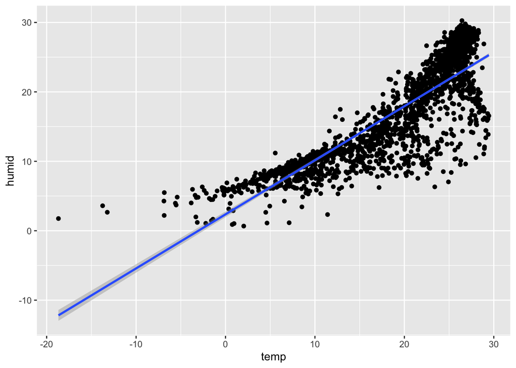

```r
print(ggplot(filtered_dengue, aes(temp, humid)) +
  geom_point() + geom_smooth(method='lm'))
```

Second method: graph residuals explicitly across X

```r
#create new empty df; add x (humid) and residuals into it
resid_data <- data.frame(filtered_dengue$temp, resids)
View(resid_data)
```

[output not shown]

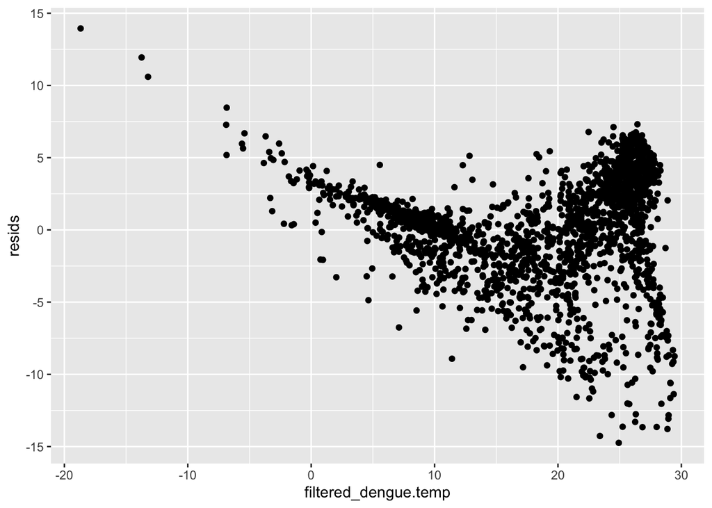

```r
print(ggplot(resid_data, aes(filtered_dengue.temp, resids)) +
  geom_point())
```

We will also assess heteroskedasticity using the ‘robust’ standard errors:

```r
library(sandwich)
```

```r
m7b <- msummary(m7,vcov = 'robust', stars=c('*' = .1, '**' = .05, '***' = .01), output='regression_table_5.html')
```

8. In the graph in the last problem you may have noticed that for certain ranges of temperate, the errors were clearly nonzero on average. This can indicate a functional form problem. Run the model from question 7 again (with heteroskedasticity-robust standard errors), but this time use the logarithm of humidity in place of humidity. Add a sentence interpreting the coefficient on temperature.

*Language-specific instructions*:

- In Python and R, store the model as `m8`. In R, use the `msummary()` function from the **modelsummary** package to display the results with the `stars = TRUE` option.

In Stata, you’ll need to create logged humidity in the data before running the regression. In R and Python you can do it inside of the regression formula, using `np.log()` from **numpy** in Python.

```r
m8 <- lm(log(humid)~temp, data = filtered_dengue)
```

```r
msummary(m8, vcov='robust', stars=c('*' = .1, '**' = .05, '***' = .01), output='regression_table_6.html')
```

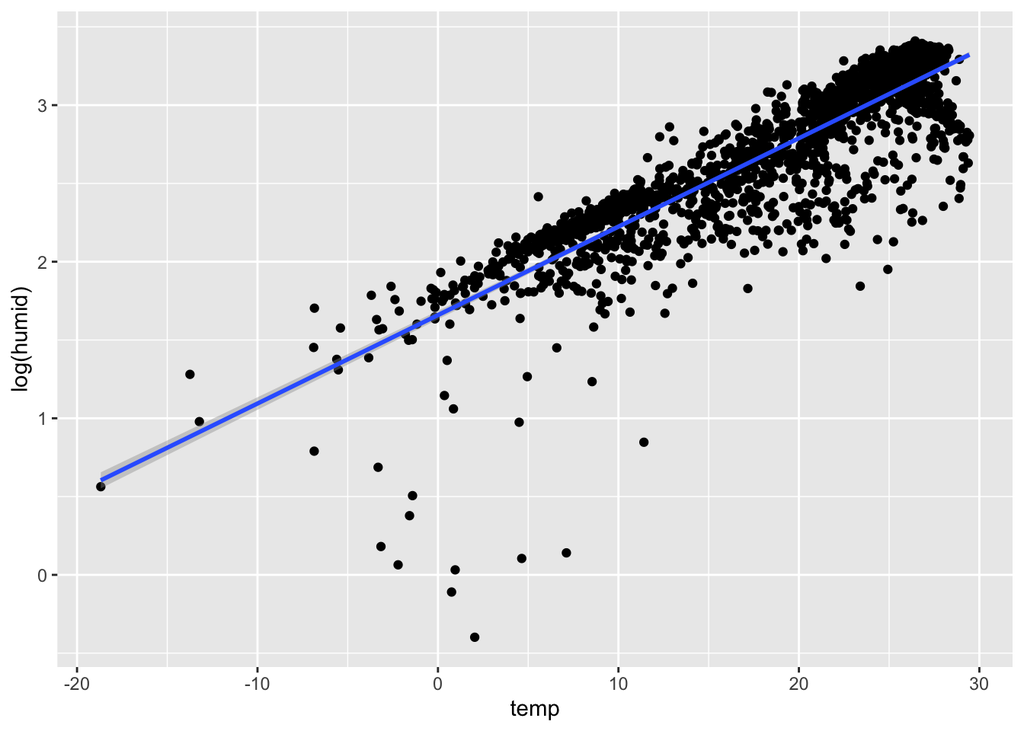

```r
print(ggplot(filtered_dengue, aes(temp, log(humid))) +
  geom_point() + geom_smooth(method='lm'))
```

9. Bonus challenge: figure out how I decided on a form where you log humidity and keep temperature linear.

As seen in the above graphs, the relationship between temperature and humidity (without logging), has a slight rightward skew with a few outliers close to low values of X (around -20). We know from Chapt 13 that one of the solutions to making a skewed relationship with outliers appear more linear is to log the outcome variable. Perhaps the author observed the shape of the relationship in question 7 and decided to try logging to mitigate the influence of outliers and address the rightward skew.